# Supervised Learning

## Non-parametric models

### Tree methods

```python
import pandas as pd
import numpy as np
import seaborn as sns
import scipy.stats
import matplotlib.pyplot as plt
%matplotlib inline
```

Preprocessing steps of the dataset from file `homes.csv`

```python
filepath = 'data/homes.csv'
dataset = pd.read_csv(filepath, header = 0, sep = ',')
```

```python
dataset.drop(['id','date', 'sqft_living15', 'lat', 'long', 'sqft_lot15', 'zipcode'], axis = 1, inplace = True)
```

```python
dataset.shape
```

```
(21613, 14)
```

```python
dataset.dtypes
```

```
price              int64
bedrooms           int64
bathrooms        float64
sqft_living        int64
sqft_lot           int64
floors           float64
waterfront         int64
view               int64
condition          int64
grade              int64
sqft_above         int64
sqft_basement      int64
yr_built           int64
yr_renovated       int64
dtype: object
```

```python
dataset.yr_built = [2015 - yr for yr in dataset.yr_built]
dataset.yr_renovated = [2015 - yr if yr != 0 else yr for yr in dataset.yr_renovated]
```

```python
new_cols = dataset.columns[0:6].tolist() + dataset.columns[-4:].tolist() + dataset.columns[6:10].tolist()
dataset = dataset[new_cols]
```

```python
dataset.head(10)
```

|  | price | bedrooms | bathrooms | sqft_living | sqft_lot | floors | sqft_above | sqft_basement | yr_built | yr_renovated | waterfront | view | condition | grade |
| --- | --- | --- | --- | --- | --- | --- | --- | --- | --- | --- | --- | --- | --- | --- |
| 0 | 221900 | 3 | 1.00 | 1180 | 5650 | 1.0 | 1180 | 0 | 60 | 0 | 0 | 0 | 3 | 7 |
| 1 | 538000 | 3 | 2.25 | 2570 | 7242 | 2.0 | 2170 | 400 | 64 | 24 | 0 | 0 | 3 | 7 |
| 2 | 180000 | 2 | 1.00 | 770 | 10000 | 1.0 | 770 | 0 | 82 | 0 | 0 | 0 | 3 | 6 |
| 3 | 604000 | 4 | 3.00 | 1960 | 5000 | 1.0 | 1050 | 910 | 50 | 0 | 0 | 0 | 5 | 7 |
| 4 | 510000 | 3 | 2.00 | 1680 | 8080 | 1.0 | 1680 | 0 | 28 | 0 | 0 | 0 | 3 | 8 |
| 5 | 1225000 | 4 | 4.50 | 5420 | 101930 | 1.0 | 3890 | 1530 | 14 | 0 | 0 | 0 | 3 | 11 |
| 6 | 257500 | 3 | 2.25 | 1715 | 6819 | 2.0 | 1715 | 0 | 20 | 0 | 0 | 0 | 3 | 7 |
| 7 | 291850 | 3 | 1.50 | 1060 | 9711 | 1.0 | 1060 | 0 | 52 | 0 | 0 | 0 | 3 | 7 |
| 8 | 229500 | 3 | 1.00 | 1780 | 7470 | 1.0 | 1050 | 730 | 55 | 0 | 0 | 0 | 3 | 7 |
| 9 | 323000 | 3 | 2.50 | 1890 | 6560 | 2.0 | 1890 | 0 | 12 | 0 | 0 | 0 | 3 | 7 |

we know from workshop_1 that the variables `condition` and `grade` start at level `1`.

in order to avoid the additional step of `LabelEncoder()` we can simply subtract 1 from every element of the column

```python
dataset.condition = [i-1 for i in dataset.condition]
```

```python
dataset.grade = [i-1 for i in dataset.grade]
```

```python
dataset.head(10)
```

|  | price | bedrooms | bathrooms | sqft_living | sqft_lot | floors | sqft_above | sqft_basement | yr_built | yr_renovated | waterfront | view | condition | grade |
| --- | --- | --- | --- | --- | --- | --- | --- | --- | --- | --- | --- | --- | --- | --- |
| 0 | 221900 | 3 | 1.00 | 1180 | 5650 | 1.0 | 1180 | 0 | 60 | 0 | 0 | 0 | 2 | 6 |
| 1 | 538000 | 3 | 2.25 | 2570 | 7242 | 2.0 | 2170 | 400 | 64 | 24 | 0 | 0 | 2 | 6 |
| 2 | 180000 | 2 | 1.00 | 770 | 10000 | 1.0 | 770 | 0 | 82 | 0 | 0 | 0 | 2 | 5 |
| 3 | 604000 | 4 | 3.00 | 1960 | 5000 | 1.0 | 1050 | 910 | 50 | 0 | 0 | 0 | 4 | 6 |
| 4 | 510000 | 3 | 2.00 | 1680 | 8080 | 1.0 | 1680 | 0 | 28 | 0 | 0 | 0 | 2 | 7 |
| 5 | 1225000 | 4 | 4.50 | 5420 | 101930 | 1.0 | 3890 | 1530 | 14 | 0 | 0 | 0 | 2 | 10 |
| 6 | 257500 | 3 | 2.25 | 1715 | 6819 | 2.0 | 1715 | 0 | 20 | 0 | 0 | 0 | 2 | 6 |
| 7 | 291850 | 3 | 1.50 | 1060 | 9711 | 1.0 | 1060 | 0 | 52 | 0 | 0 | 0 | 2 | 6 |
| 8 | 229500 | 3 | 1.00 | 1780 | 7470 | 1.0 | 1050 | 730 | 55 | 0 | 0 | 0 | 2 | 6 |
| 9 | 323000 | 3 | 2.50 | 1890 | 6560 | 2.0 | 1890 | 0 | 12 | 0 | 0 | 0 | 2 | 6 |

```python
dataset.waterfront = dataset.waterfront.astype('category')
dataset.view = dataset.view.astype('category')
dataset.grade = dataset.grade.astype('category')
dataset.condition = dataset.condition.astype('category')
```

```python
dataset.dtypes
```

```
price               int64
bedrooms            int64
bathrooms         float64
sqft_living         int64
sqft_lot            int64
floors            float64
sqft_above          int64
sqft_basement       int64
yr_built            int64
yr_renovated        int64
waterfront       category
view             category
condition        category
grade            category
dtype: object
```

```python
from sklearn.metrics import mean_squared_error
from sklearn.tree import DecisionTreeRegressor
from sklearn.model_selection import train_test_split
from sklearn.preprocessing import OneHotEncoder
```

```python
x_train, x_test, y_train, y_test = train_test_split(dataset.iloc[:,1:], dataset.iloc[:,0], test_size = .2, random_state = 43)
```

```python
enc = OneHotEncoder(categorical_features = [9,10,11,12])
```

```python
dataset_ = enc.fit(dataset).transform(dataset).toarray()
dataset_
```

```
array([[  1.,   0.,   0., ...,   0.,  60.,   6.],
       [  0.,   0.,   0., ..., 400.,  64.,   6.],
       [  1.,   0.,   0., ...,   0.,  82.,   5.],
       ...,
       [  1.,   0.,   0., ...,   0.,   6.,   6.],
       [  1.,   0.,   0., ...,   0.,  11.,   7.],
       [  1.,   0.,   0., ...,   0.,   7.,   6.]])
```

# Tree Regression

<a href = 'http://scikit-learn.org/stable/modules/generated/sklearn.tree.DecisionTreeRegressor.html'>link</a>

```
DecisionTreeRegressor(criterion='mse',
                        max_depth=None,
                        min_samples_split=2,
                        min_samples_leaf=1,
                        max_features=None,
                        random_state=None,
                        min_impurity_decrease=0.0)
```

`criterion`: `mse` or `mae`  
`max_depth`: the maximum depth of a tree. if not specified more nodes will be added until the leaves are pure  
`min_samples_split`: the miniumum number of samples required to split a node  
`min_sample_leaf`: the minimum number of samples required to become a leaf node  
`max_features`: the number of features to consider when looking for the best split  
`random_state`: seed  
`min_impurity_decrease`: a node will be split if this split induces a decrease of the impurity greater than or equal to this value

```python
tree = DecisionTreeRegressor(criterion = 'mse',
                             splitter = 'best',
                             max_depth = 10,
                             min_samples_split = 70)
```

```python
tree.fit(X = x_train, y  = np.log(y_train))
```

```
DecisionTreeRegressor(criterion='mse', max_depth=10, max_features=None,
           max_leaf_nodes=None, min_impurity_decrease=0.0,
           min_impurity_split=None, min_samples_leaf=1,
           min_samples_split=70, min_weight_fraction_leaf=0.0,
           presort=False, random_state=None, splitter='best')
```

```python
y_train_pred_tree = tree.predict(x_train)
```

```python
from bokeh.io import output_notebook, show
from bokeh.plotting import figure
output_notebook()
```

```python
p = figure(plot_width = 800, plot_height = 400)
p.scatter(range(x_train.shape[0]), np.log(y_train - y_train_pred_tree), color = 'purple')
show(p)
```

[interactive chart not shown]

```python
p = figure(plot_width = 700, plot_height = 400)
p.scatter(np.log(y_train_pred_tree), np.log(y_train - y_train_pred_tree), color = 'purple')
show(p)
```

[interactive chart not shown]

```python
tree.feature_importances_
```

```
array([0.00242728, 0.00779664, 0.15302339, 0.03259662, 0.00535523,
       0.0042125 , 0.0033662 , 0.12371062, 0.0008279 , 0.00400656,
       0.0110186 , 0.00579688, 0.64586157])
```

```python
df_tree = pd.DataFrame(tree.feature_importances_, dataset.columns[1:], columns = ['value']).sort_values(by = ['value'], ascending = True)
```

```
<BarContainer object of 13 artists>
```

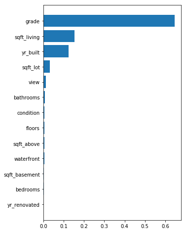

```python
plt.figure(figsize = (5,8))
plt.barh(width = df_tree.value, y = df_tree.index)
```

```python
y_pred_tree = tree.predict(x_test)
```

```python
y_pred_tree
```

```
array([13.22405495, 12.6775648 , 13.22913693, ..., 12.88391009,
       13.61461309, 12.42420198])
```

```python
mean_squared_error(y_true = np.log(y_test), y_pred = y_pred_tree)
```

```
0.09870598273423774
```

# Random Forest Regression

```
RandomForestRegressor(n_estimators=10,
                        criterion='mse',
                        max_depth=None,
                        min_samples_split=2,
                        min_samples_leaf=1,
                        max_features='auto',
                        max_leaf_nodes=None,
                        min_impurity_decrease=0.0,
                        min_impurity_split=None,
                        bootstrap=True,
                        n_jobs=1,
                        random_state=None,
                        verbose=0)
```

`n_estimators=10`: number of trees in the forest  
`criterion`: `mse` or `mae`  
`max_depth`: the maximum depth of a tree. if not specified more nodes will be added until the leaves are pure  
`min_samples_split`: the miniumum number of samples required to split a node  
`min_sample_leaf`: the minimum number of samples required to become a leaf node  
`max_features`: the number of features to consider when looking for the best split  
`random_state`: seed  
`min_impurity_decrease`: a node will be split if this split induces a decrease of the impurity greater than or equal to this value  
`n_jobs`: the number of jobs to run in parallel for both fit and predict

```python
from sklearn.ensemble import RandomForestRegressor
```

```python
rf = RandomForestRegressor(n_estimators = 150,
                        criterion='mse',
                        max_depth = 6,
                        min_samples_split =20,
                        bootstrap = True,
                        n_jobs = 10)
```

```python
rf.fit(X = x_train, y = np.log(y_train))
```

```
RandomForestRegressor(bootstrap=True, criterion='mse', max_depth=6,
           max_features='auto', max_leaf_nodes=None,
           min_impurity_decrease=0.0, min_impurity_split=None,
           min_samples_leaf=1, min_samples_split=20,
           min_weight_fraction_leaf=0.0, n_estimators=150, n_jobs=10,
           oob_score=False, random_state=None, verbose=0, warm_start=False)
```

```python
rf.feature_importances_
```

```
array([3.27263812e-04, 3.51933165e-03, 1.62130841e-01, 1.56688623e-02,
       1.35420330e-03, 2.79406877e-03, 3.00254135e-03, 1.14721517e-01,
       3.92928322e-04, 3.26018378e-03, 7.42221262e-03, 8.28967972e-04,
       6.84577078e-01])
```

```python
df_rf = pd.DataFrame(rf.feature_importances_, dataset.columns[1:], columns = ['value']).sort_values(by = ['value'], ascending = True)
```

```
<BarContainer object of 13 artists>
```

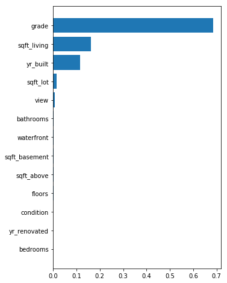

```python
plt.figure(figsize = (5,8))
plt.barh(width = df_rf.value, y = df_rf.index)
```

```python
y_train_pred_rf = rf.predict(x_train)
```

```python
p = figure(plot_width = 800, plot_height = 400)
p.scatter(range(x_train.shape[0]), np.log(y_train - y_train_pred_rf), color = 'purple')
show(p)
```

[interactive chart not shown]

```python
p = figure(plot_width = 700, plot_height = 400)
p.scatter(np.log(y_train_pred_tree), np.log(y_train - y_train_pred_rf), color = 'purple')
show(p)
```

[interactive chart not shown]

```python
y_pred_rf = rf.predict(x_test)
```

```python
mean_squared_error(y_true = np.log(y_test), y_pred = y_pred_rf)
```

```
0.09530820386990961
```